# OBIWAN BEHAVIORAL ANALYSIS

David Munoz Tord

2020-12-03

## Setup

May I suggest running `repro::automate()`? This will create a `Dockerfile` & `Makefile` based on every RMarkdown in this folder and the special yamls in them.

If you are unsure weather or not you have `git` `make` & `docker`.

```
## ✓ Git is installed, don't worry.
```

```
## ✓ Make is installed, don't worry.
```

```
## ✓ Docker is installed, don't worry.
```

### Demographics

Summary statistics AGE

| group | mean | sd | min | max |
| --- | --- | --- | --- | --- |
| Lean | 35.23077 | 12.61042 | 19 | 67 |
| Obese | 38.65574 | 12.25650 | 18 | 64 |

Summary statistics BMI

| group | mean | sd | min | max |
| --- | --- | --- | --- | --- |
| Lean | 22.37308 | 1.826246 | 18.6 | 24.8 |
| Obese | 35.46066 | 3.145731 | 30.5 | 44.1 |

Summary statistics GENDER

| gender | group | n |
| --- | --- | --- |
| Men | Lean | 12 |
| Men | Obese | 19 |
| Women | Lean | 14 |
| Women | Obese | 42 |

N by groups

| group | n |
| --- | --- |
| Lean | 26 |
| Obese | 61 |

## Pavlvovian Conditioning Task

### Analysis: Reaction Times

Model Selection we followed Barr et al. (2013) approach to contruct random structure and covariates SEE –> R/MS_PAV_T0.R  
Formula = RT_T ~ condition*group + (condition|id) + (1|trialxcondition)

|  | Reaction Times (log) |  |
| --- | --- | --- |
| Predictors | Estimates | std. Error |
| condition [1] | -0.015 | 0.007 |
| group [1] | -0.031 | 0.025 |
| condition [1] * group [1] | 0.004 | 0.007 |
| ICC | 0.45 |  |
| N <sub>id</sub> | 87 |  |
| N <sub>trialxcondition</sub> | 20 |  |
| Observations | 3244 |  |
| Marginal R<sup>2</sup> / Conditional R<sup>2</sup> | 0.010 / 0.456 |  |

Parametric Bootstrap Test method to evaluate significance of fixed effects in mixed-effects models (using MLE fit, nsim = 500)

| Effect | df | Chisq | p.value |
| --- | --- | --- | --- |
| condition | 1 | 4.88 * | .020 |
| group | 1 | 1.52 | .224 |
| condition:group | 1 | 0.35 | .469 |

Extract BF from mixed models see Wagenmakers, 2007

BF = 5.112141

### Reaction Times by condition

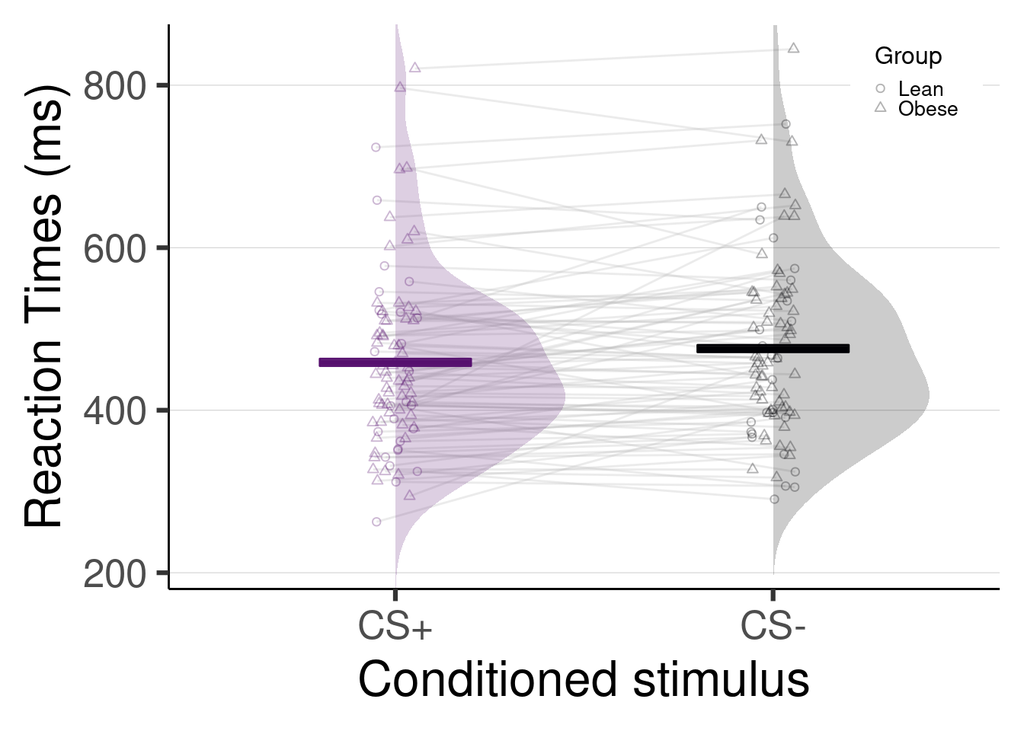

### Analysis: Pleasantness Ratings

Using ANOVA here because no hierarchical structure  
Formula = liking ~ condition*group + Error (id/condition)

| Effect | df | MSE | F | pes | p.value |
| --- | --- | --- | --- | --- | --- |
| group | 1, 85 | 242.63 | 0.13 | .002 | .716 |
| condition | 1, 85 | 248.30 | 35.01 *** | .292 | <.001 |
| group:condition | 1, 85 | 248.30 | 0.57 | .007 | .452 |

Bayes factor

| bf | error |
| --- | --- |
| 8.172954e+08 | 0.0056670 |
| 2.046345e-01 | 0.0080366 |
| 1.766773e+08 | 0.0119324 |
| 6.033185e+07 | 0.0187752 |

### Pleasantness Ratings by condition

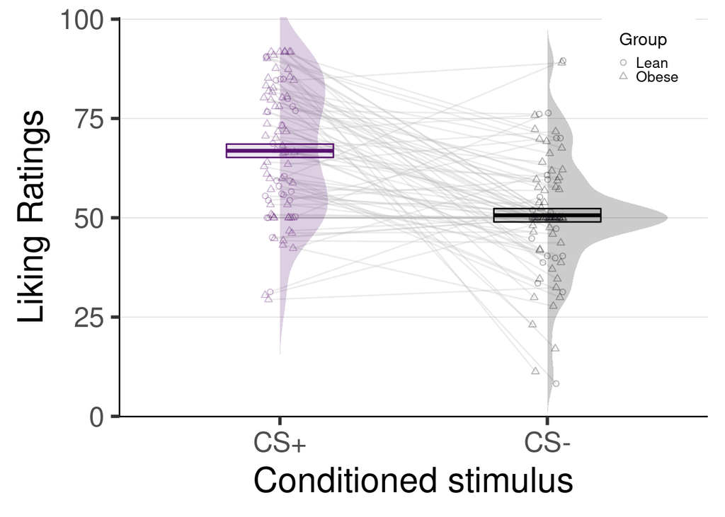

## Instrumental Conditioning Task

### Analysis: Number of Grips

Model selection we followed Barr et al. (2013) approach to contruct random structure and covariates SEE –> R/MS_INST.R  
Formula = grips ~ trial*group + thirsty + hungry + piss + (1 | id)  
Model Comparison between linear, quadratic, cubic and spline(5)

Piecewise Regression with Splines has the best fit

| Model | BF |
| --- | --- |
| trial * group + thirsty + hungry + piss + (1 \| id) | 1.00000 |
| trial + I(trial^2) * group + thirsty + hungry + piss + (1 \| id) | 45.80707 |
| trial + I(trial^2) + I(trial^3) * group + thirsty + hungry + piss + (1 \| id) | 103.25314 |
| lspline(trial, 5) * group + thirsty + hungry + piss + (1 \| id) | 771.74002 |

|  | Number of grips |  |
| --- | --- | --- |
| Predictors | Estimates | std. Error |
| trial [1st degree] | 0.347 | 0.087 |
| trial [2nd degree] | -0.107 | 0.014 |
| group [1] | -0.555 | 0.845 |
| thirsty | -0.302 | 0.785 |
| hungry | -0.458 | 0.778 |
| piss | -0.270 | 0.710 |
| trial [1st degree] * group [1] | -0.014 | 0.087 |
| trial [2nd degree] * group [1] | 0.017 | 0.014 |
| ICC | 0.79 |  |
| N <sub>id</sub> | 84 |  |
| Observations | 2016 |  |
| Marginal R<sup>2</sup> / Conditional R<sup>2</sup> | 0.022 / 0.799 |  |

| Effect | df | Chisq | p.value |
| --- | --- | --- | --- |
| ls1 | 1 | 15.75 * | .020 |
| ls2 | 1 | 55.03 * | .020 |
| group | 1 | 0.43 | .388 |
| thirsty | 1 | 0.15 | .694 |
| hungry | 1 | 0.35 | .592 |
| piss | 1 | 0.14 | .673 |
| ls1:group | 1 | 0.02 | .837 |
| group:ls2 | 1 | 1.35 | .204 |

### Number of Grips over time

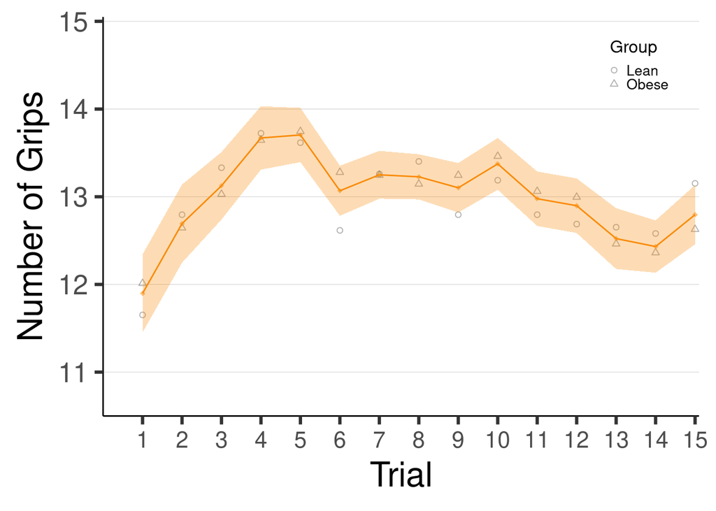

## Pavlvovian-Instrumental Transfer (PIT) Task

### Analysis: Mobilized effort (AUC)

Model selection we followed Barr et al. (2013) approach to contruct random structure and covariates SEE –> R/MS_PIT.R  
Formula = AUC ~ condition*group + hungry + hungry:condition + (condition|id) + (1|trialxcondition)

|  | Mobilized effort (AUC) |  |
| --- | --- | --- |
| Predictors | Estimates | std. Error |
| condition [1] | 1.592 | 2.070 |
| group [1] | -9.142 | 9.971 |
| hungry | -10.314 | 9.151 |
| condition [1] * group [1] | -4.330 | 2.086 |
| condition [1] * hungry | 3.758 | 1.915 |
| ICC | 0.75 |  |
| N <sub>id</sub> | 83 |  |
| N <sub>trialxcondition</sub> | 15 |  |
| Observations | 2490 |  |
| Marginal R<sup>2</sup> / Conditional R<sup>2</sup> | 0.023 / 0.754 |  |

Parametric Bootstrap Test method to evaluate significance of fixed effects in mixed-effects models (using MLE fit, nsim = 500)

| Effect | df | Chisq | p.value |
| --- | --- | --- | --- |
| condition | 1 | 0.61 | .424 |
| group | 1 | 0.86 | .339 |
| hungry | 1 | 1.30 | .251 |
| condition:group | 1 | 4.35 * | .047 |
| condition:hungry | 1 | 3.90 + | .076 |

Extract BF from mixed models see Wagenmakers, 2007

BF = 3.2428322

Post-Hoc test (pairwise~ condition|group, adjust = “tukey”, side = “>”)

| contrast | group | estimate | SE | lower.CL | upper.CL | df | t | p |
| --- | --- | --- | --- | --- | --- | --- | --- | --- |
| CS+ > CS- | Lean | -5.477372 | 6.957139 | -19.322520 | 8.367776 | 26 | -0.7873023 | 0.7832844 |
| CS+ > CS- | Obese | 11.844269 | 4.550623 | 2.788241 | 20.900298 | 61 | 2.6027796 | 0.0055084 |

### Mobilized effort (AUC) difference (CS+ > CS-) by group

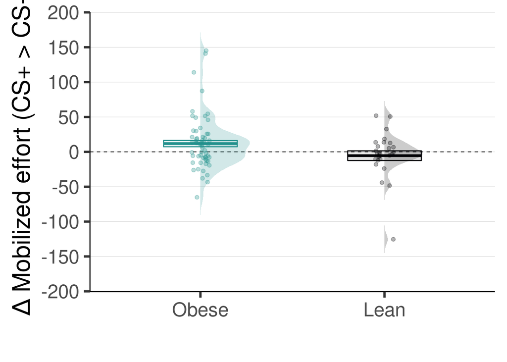